# Final Assignment

Ozan Kaya

April 6, 2021

## Introduction

When we take a look at the yearly summary of the gaming data, we can see that the avg and peak values are extremely skewed. The right tail is rather long. It is not surprising to see this since we should expect some of the games to dominate the gaming world. There should be also many games that have failed to peak the interest of gamers. Therefore, averages misses important information if we are to make an analysis of the data we have. We should focus on the extremes.

Summary of Average Gamer Count

| year | Min. | 1st Qu. | Median | Mean | 3rd Qu. | Max. |
| --- | --- | --- | --- | --- | --- | --- |
| 2021 | 0.69 | 55.92 | 309.41 | 3477.40 | 1231.81 | 743209.7 |
| 2020 | 0.18 | 53.11 | 255.79 | 3144.16 | 1019.29 | 857604.2 |
| 2019 | 0.09 | 45.19 | 190.46 | 2546.16 | 702.07 | 586505.8 |
| 2018 | 0.00 | 53.86 | 199.03 | 2998.47 | 718.37 | 1584886.8 |
| 2017 | 0.00 | 51.61 | 186.68 | 2822.34 | 715.04 | 1436158.5 |
| 2016 | 0.00 | 55.92 | 178.87 | 2598.11 | 683.56 | 709178.3 |
| 2015 | 0.00 | 63.35 | 203.76 | 2744.23 | 686.31 | 628970.4 |
| 2014 | 0.00 | 58.40 | 202.34 | 2489.94 | 687.62 | 537018.7 |
| 2013 | 0.00 | 44.50 | 191.89 | 1978.44 | 686.88 | 366606.5 |
| 2012 | 0.00 | 52.61 | 211.57 | 1766.58 | 715.26 | 121924.4 |

Summary of Peak Gamer Count

| year | Min. | 1st Qu. | Median | Mean | 3rd Qu. | Max. |
| --- | --- | --- | --- | --- | --- | --- |
| 2021 | 3 | 137.75 | 679.0 | 6361.92 | 2444.50 | 1124553 |
| 2020 | 1 | 129.00 | 565.5 | 5966.04 | 2052.50 | 1305714 |
| 2019 | 2 | 117.00 | 435.0 | 4979.84 | 1511.00 | 1084606 |
| 2018 | 0 | 136.00 | 475.0 | 6163.61 | 1560.00 | 3236027 |
| 2017 | 0 | 135.00 | 473.5 | 5599.39 | 1647.25 | 3080769 |
| 2016 | 0 | 146.00 | 463.0 | 5087.80 | 1564.75 | 1291328 |
| 2015 | 0 | 170.00 | 539.0 | 5493.46 | 1648.25 | 1262612 |
| 2014 | 0 | 166.00 | 568.0 | 5109.87 | 1865.25 | 963810 |
| 2013 | 0 | 128.00 | 533.0 | 4196.62 | 1917.00 | 702792 |
| 2012 | 0 | 148.00 | 519.0 | 3737.87 | 1835.00 | 213521 |

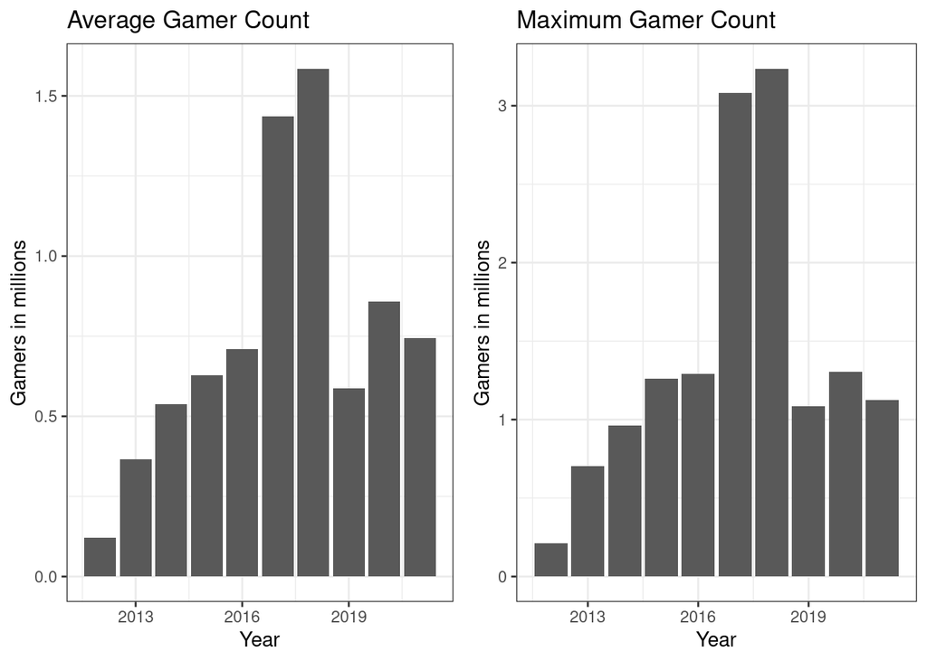

## Games

Peak Gamer Cout per Year

| gamename | peak | gaming_date | release_date |
| --- | --- | --- | --- |
| Counter-Strike: Global Offensive | 1124553 | 2021-01-01 | Aug 21, 2012 |
| Counter-Strike: Global Offensive | 1305714 | 2020-04-01 | Aug 21, 2012 |
| PLAYERUNKNOWN’S BATTLEGROUNDS | 1084606 | 2019-01-01 | Dec 21, 2017 |
| PLAYERUNKNOWN’S BATTLEGROUNDS | 3236027 | 2018-01-01 | Dec 21, 2017 |
| PLAYERUNKNOWN’S BATTLEGROUNDS | 3080769 | 2017-12-01 | Dec 21, 2017 |
| Dota 2 | 1291328 | 2016-03-01 | Jul 9, 2013 |
| Dota 2 | 1262612 | 2015-02-01 | Jul 9, 2013 |
| Dota 2 | 963810 | 2014-11-01 | Jul 9, 2013 |
| Dota 2 | 702792 | 2013-11-01 | Jul 9, 2013 |
| Dota 2 | 213521 | 2012-12-01 | Jul 9, 2013 |

Average Gamer Count per Year

| gamename | avg | gaming_date | release_date |
| --- | --- | --- | --- |
| Counter-Strike: Global Offensive | 743209.7 | 2021-01-01 | Aug 21, 2012 |
| Counter-Strike: Global Offensive | 857604.2 | 2020-04-01 | Aug 21, 2012 |
| Dota 2 | 586505.8 | 2019-03-01 | Jul 9, 2013 |
| PLAYERUNKNOWN’S BATTLEGROUNDS | 1584886.8 | 2018-01-01 | Dec 21, 2017 |
| PLAYERUNKNOWN’S BATTLEGROUNDS | 1436158.5 | 2017-12-01 | Dec 21, 2017 |
| Dota 2 | 709178.3 | 2016-02-01 | Jul 9, 2013 |
| Dota 2 | 628970.4 | 2015-02-01 | Jul 9, 2013 |
| Dota 2 | 537018.7 | 2014-07-01 | Jul 9, 2013 |
| Dota 2 | 366606.5 | 2013-12-01 | Jul 9, 2013 |
| Dota 2 | 121924.4 | 2012-12-01 | Jul 9, 2013 |

The above information suggests that the top games that drives the peak and average numbers we see are Counter-Strike, Dota 2, PUBG and less so the Cyberpunk and Fallout 4 (from an offline query). Note that Fallout and Cyberpunk are singleplayer games and they tend to have a lower concentration of players on a given time since they don’t require cooperation of any kind. Something else that we could point out is that PUBG’s success seems to come just after the release of the game and shwos a steady decline in the following months. Dota 2 on the other hand seems to have built its fan base over the years.

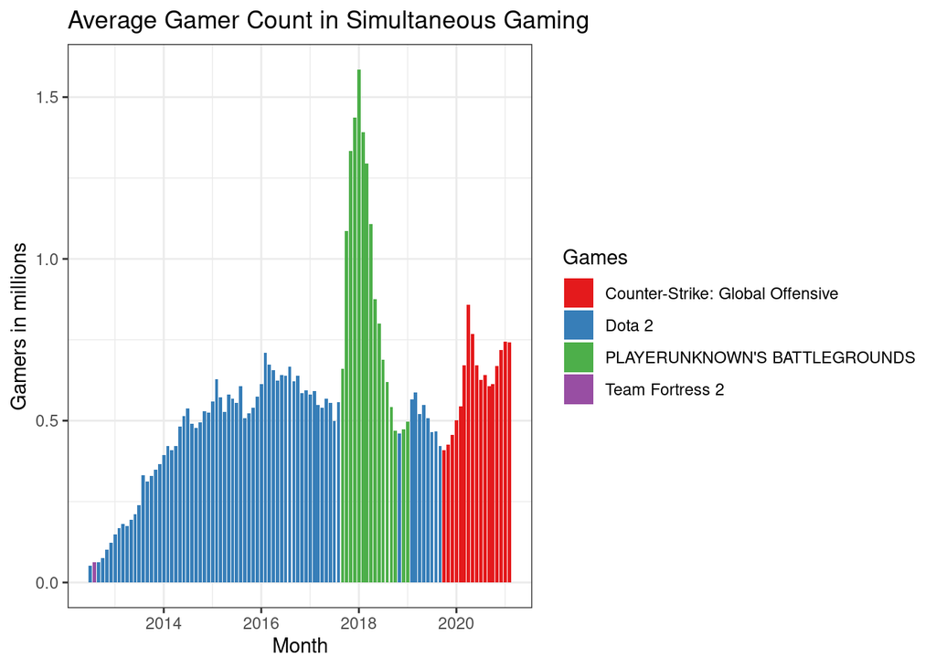

The above graph shows the difference in maximum average gamer count per month from 2012 to 2021. We have seen these values in a yearly level but we didn’t checked which games were actually played at a monthly level. Adding color as an extra dimension offers us a nice and easy visualization to this end.

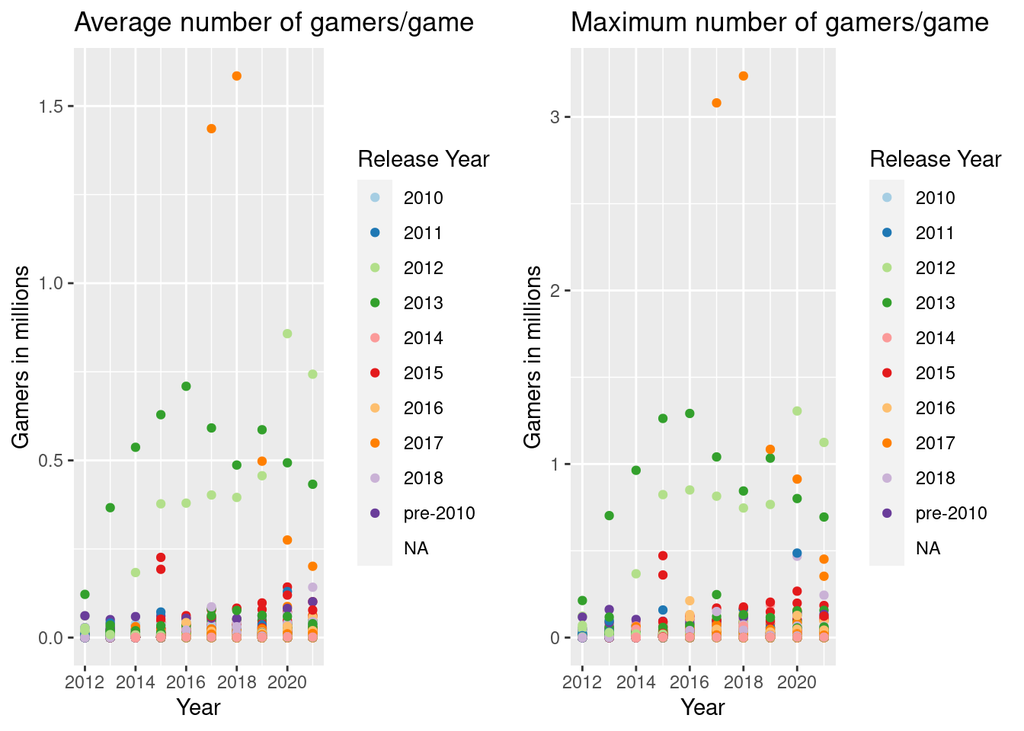

This is another representation of the playtime PUBG (released at 2017) enjoys over the years. We can also see Dota’s (released at 2013) prominence over the years as well as Counter-Strike’s (released at 2012) comeback. There are many games that are below the 200.000 average gamer count at the same time and between 100.000 and 200.000, we can see some familiar names such as Fallout 4, Cyberpunk 2077, Civilization 5, GTA 5, Rust and Terraria.

## Results

I will speculate here that the interest on PUBG was arguably exogenous. Namely, new gamers’ seem to have started playing the game on 2017 and 2018 (perhaps changed platforms) and leave the scene after their interest has burned out (Perhaps returned to their otherwise favourite gaming platform). The other most obvious result is the dominance of multiplayer games for our metrics. If we keep looking at maximum average and peak player count at a given time, we will most likely keep seeing multiplayer or co-op games. If we were to check the total amount of playtime, singleplayer games might had had a shot, especially when they were first released.

## Appendix 1

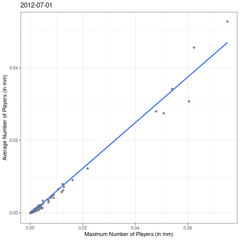

## Appendix 2

If we take look at the seasonal changes in our data, we can also see that there is a slight seasonality for our games. The major effect is due to the time trend but we also see a very slight increase in peak gamer counts in Counter-Strike around Spring and around Summer in PUBG and around the late Winter in Dota 2. The effects are rather small but it may be still worthwhile to mention them.

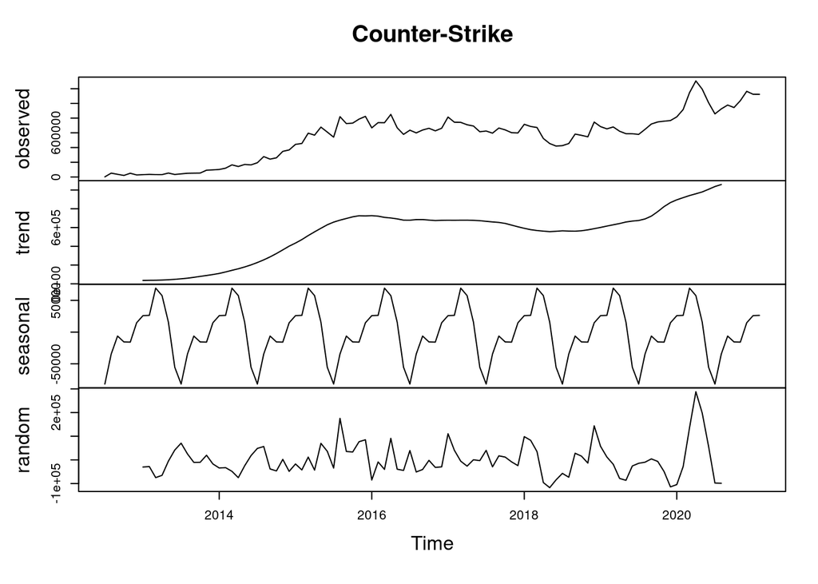

[figure not shown]

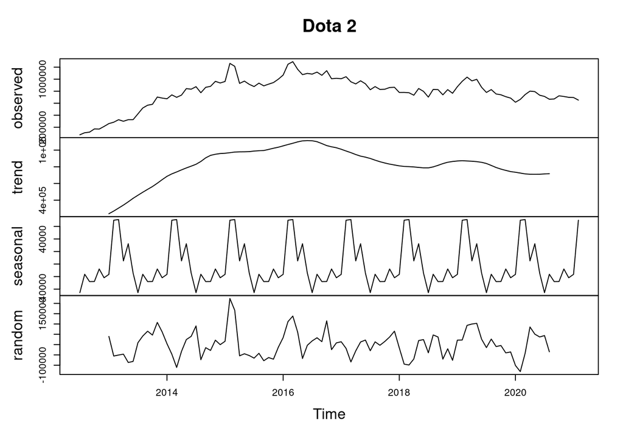